# CIND 123 - Data Analytics: Basic Methods

Marco Muto

# Assignment 1 (10%)

## Instructions

Use RStudio for this assignment. Complete the assignment by inserting your R code wherever you see the string “#INSERT YOUR ANSWER HERE”.

Submit **both** the rmd and generated output files. Failing to submit both files will be subject to mark deduction.

## Sample Question and Solution

Use `seq()` to create the vector $(1,2,3,\ldots,10)$.

```r
seq(1,10)
```

```
##  [1]  1  2  3  4  5  6  7  8  9 10
```

## Question 1

1. Use the `seq()` function to create the vector $(1, 7, 13, \ldots, 61)$. Note that each term in this sequence is of the form $1 + 6n$ where $n = 0, \ldots, 10$.

```r
seq(from=1, to=61, by=6)
```

```
##  [1]  1  7 13 19 25 31 37 43 49 55 61
```

2. Use `rep()` to create the vector $(2,3,4,\dots,2,3,4, \dots,2,3,4)$ in which the sequence $(2,3,4)$ is repeated 5 times.

```r
rep(2:4,times=5)
```

```
##  [1] 2 3 4 2 3 4 2 3 4 2 3 4 2 3 4
```

3. To convert factor to number, would it be correct to use the following commands? Explain your answer.

`factorVar <- factor(c(1, 6, 5.4, 3.2));as.numeric(factorVar)`

```r
#as.numeric(factorVar)
##as.numeric R defaults to treating the levels as if they were equidistant in the modelling code by generating polynomial contrasts. It will
##order them according from largest to smallest hence the 1,4,3,2.
```

4. A comma-separated values file `dataset.csv` consists of missing values represented by question marks (`?`) and exclamation mark (`!`). How can you read this type of files in R?

```r
#df <- read.csv(file = "dataset.csv", stringsAsFactors = F, sep = ",", na.strings = c("?","!"))
```

## Question 2

1. Compute:
   $$\sum_{n=10}^{100} n^3$$

```r
sum(seq(10:100)^3)
```

```
## [1] 17522596
```

2. Compute:
   $$\sum_{n=1}^{10}\left(\frac{2^{n}}{n^2} + \frac{n^{4}}{4^{n}}\right)$$

```r
n <- 1:10
sum(((2^n)/(n^2))+((n^4)/(4^n)))
```

```
## [1] 35.80589
```

3. Compute:
   $$\sum_{n=0}^{10} \frac{1}{(n+1)!}$$

```r
sum(1/factorial(1+(seq(10,0))))
```

```
## [1] 1.718282
```

4. Compute:
   $$\prod_{n=3}^{33} \left(3n + \frac{3}{\sqrt[3]{n}}\right)$$

```r
n <- 3:33
prod((3*n)+(3/(n^1/3)))
```

```
## [1] 7.427886e+51
```

5. Explain the output of this R-command: `c(0:5)[NA]`

```r
c(0:5)[NA]
```

```
## [1] NA NA NA NA NA NA
```

```r
##the output is a vector that repeats NA 6 times the vecor's index starts at 0 and continues to 5.
```

6. What is the difference between is.vector() and is.numeric() functions?

```r
#both functions are primitive and are used to check the data type when called. they will return true if a variable
#contains numeric vector. They may differ if a vector contains character data then it will return dalse if called via is.numeric(), And it will return true if called by is.vector.
```

7. List at least three advantages and three disadvantages of using `RShiny` package?

```r
#Three advantages include R shiny being good for non programmers to make visualizations, great for making high quality apps quickly especially if the user already knows R, the created apps are also readily avaialble and shareble #Three disadvantages are R shiny being limited in making complicated apps. Capturing user input and feedback may be difficult. Lastly R shiny may have long load times for loading apps
```

## Question 3

`iris` dataset gives the measurements in centimeters of the variables sepal length, sepal width, petal length and petal width, respectively, for 50 flowers from each of 3 species of iris. The species are Iris setosa, versicolor, and virginica.

Install the `iris` dataset on your computer using the command `install.packages("datasets")`. Then, load the `datasets` package into your session using the following command.

```r
library(datasets)
```

1. Display the first six rows of the `iris` data set.

```r
head(iris)
```

```
##   Sepal.Length Sepal.Width Petal.Length Petal.Width Species
## 1          5.1         3.5          1.4         0.2  setosa
## 2          4.9         3.0          1.4         0.2  setosa
## 3          4.7         3.2          1.3         0.2  setosa
## 4          4.6         3.1          1.5         0.2  setosa
## 5          5.0         3.6          1.4         0.2  setosa
## 6          5.4         3.9          1.7         0.4  setosa
```

2. Compute the average of the first four variables (Sepal.Length, Sepal.Width, Petal.Length and Petal.Width) using `sapply()` function.

Hint: You might need to consider removing the `NA` values, otherwise the average will not be computed.

```r
sapply(iris[1:4],mean, rm=NA)
```

```
## Sepal.Length  Sepal.Width Petal.Length  Petal.Width
##     5.843333     3.057333     3.758000     1.199333
```

3. Show how to use R to replace the missing values in this dataset with plausible ones.

```r
library(imputeTS)
na_mean(iris)
```

```
##     Sepal.Length Sepal.Width Petal.Length Petal.Width    Species
## 1            5.1         3.5          1.4         0.2     setosa
## 2            4.9         3.0          1.4         0.2     setosa
## 3            4.7         3.2          1.3         0.2     setosa
## 4            4.6         3.1          1.5         0.2     setosa
## 5            5.0         3.6          1.4         0.2     setosa
## 6            5.4         3.9          1.7         0.4     setosa
## 7            4.6         3.4          1.4         0.3     setosa
## 8            5.0         3.4          1.5         0.2     setosa
## 9            4.4         2.9          1.4         0.2     setosa
## 10           4.9         3.1          1.5         0.1     setosa
## 11           5.4         3.7          1.5         0.2     setosa
## 12           4.8         3.4          1.6         0.2     setosa
## 13           4.8         3.0          1.4         0.1     setosa
## 14           4.3         3.0          1.1         0.1     setosa
```

[output cut: 136 more lines]

4. Compute the standard deviation for only the first and the third variables (Sepal.Length and Petal.Length)

```r
sd(iris[,1])
```

```
## [1] 0.8280661
```

```r
sd(iris[,3])
```

```
## [1] 1.765298
```

5. Construct a boxplot for `Sepal.Width` variable, then display the values of all the outliers. Explain how these outliers have been calculated.

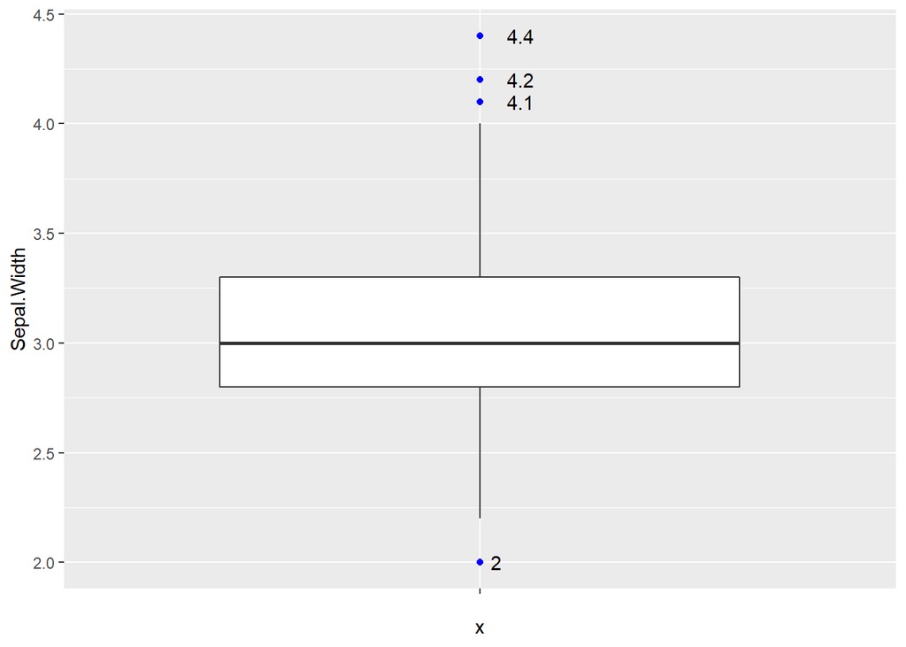

```r
require(ggplot2)
ggplot(iris,aes(x="", y=Sepal.Width))+
  geom_boxplot(outlier.color = "blue")+
  stat_summary(aes(label = round(stat(y), 1)),
               geom = "text",
               fun = function(y) { o <- boxplot.stats(y)$out; if(length(o) == 0) NA else o },
               hjust = -1
  )
```

```r
## the calculation is done by multiplying 1.5 by the IQR. If the point is larger than Q3 and less than Q1 after the calculation it is considered an outlier.
```

6. Compute the upper quartile of the `Sepal.Width` variable with two different methods.

```r
quantile(iris$Sepal.Width, 0.75)
```

```
## 75%
## 3.3
```

```r
fivenum(iris$Sepal.Width)
```

```
## [1] 2.0 2.8 3.0 3.3 4.4
```

```r
#the fourth value contains the upper quartile
```

7. Construct a pie chart to describe the species with ‘Sepal.Length’ less than 7 centimeters.

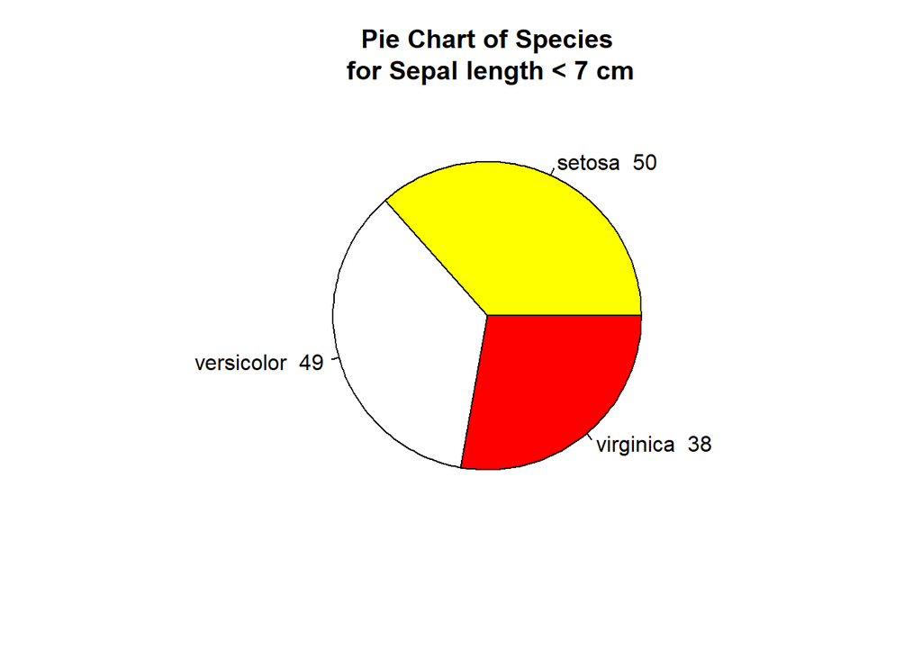

```r
sepalLength2 <- subset(iris, iris$Sepal.Length < 7)
mytable <- table(sepalLength2$Species)
lbls <- paste(names(mytable), "  \t", mytable, sep="")
pie(mytable, labels = lbls,col=c("yellow","white","red"),
   main="Pie Chart of Species\n for Sepal length < 7 cm")
```

END of Assignment #1.